# NEPA Decarbonization Technology Analysis: Deliverable 3

NEPA Review Patterns: Fossil Fuel vs. Decarbonization Projects

Published

August 21, 2026

## Executive Summary

**NoteKey Findings**

This report delivers:

> A comparison of how fossil fuel and decarbonization projects move through NEPA, including CE/EA/EIS rates by technology, categorical exclusion citation patterns, geographic distributions, visual-impact discussion patterns, and an all-agency geothermal vs. oil-and-gas comparison.

# Methodology

Deliverable 3 scopes the analysis to 31,508 energy projects — 20,725 decarbonization and 10,783 fossil fuel — drawn from NEPATEC 2.0 by excluding projects classified as `Other`. Review-process, citation, and geographic patterns are built from project metadata; visual-impact patterns are extracted from EA/EIS document text. The pipeline runs in four stages:

1 · Scope the energy universe

Filter NEPATEC 2.0's `projects_combined.parquet` to the 31,508 **Clean** and **Fossil** energy projects; projects classified as **Other** are excluded so the clean/fossil comparison is not diluted by unrelated federal actions

↓

2 · Build the review dataset

`02_build_nepa_reviews.py` assigns each project an energy group and technology tag, its review process (CE / EA / EIS), lead agency and geography, normalized CE citations, a linear-vs-non-linear geometry flag, and Deliverable 1 NEPA-trigger classifications (clean-energy projects)

↓

3 · Extract visual-impact text

For EA / EIS projects, heading-anchored retrieval pulls visual-resource sections; sentence-transformer embeddings (all-MiniLM-L6-v2) support NMF topic modeling and CEQ-anchored framing scores

↓

4 · Generate figures and tables

`04_create_figures.R` produces the review-rate, CE-citation, geography, geometry, visual-impact, and geothermal outputs read by this report

↓

Deliverable 3 report

A comparison of how **decarbonization** and **fossil fuel** projects move through NEPA

The main project-level output is `phase2/data/analysis/deliverable03/projects_nepa_reviews.parquet` — one row per project with energy category, technology group, review process, lead agency, geography, geometry, and clean-energy trigger information. The components currently available are:

| Component | Status | Notes |
| --- | --- | --- |
| Review process type | Complete | CE, EA, and EIS populated for clean and fossil projects |
| Technology group | Complete | Derived from NEPATEC project-type labels |
| CE citations | Complete | Parsed and normalized from document-level CE categories |
| Geography | Complete | State and county fields are exploded from project metadata; multi-state projects can count in multiple states |
| Visual impacts | Complete | Full visual-section text extracted from EA/EIS pages via heading-anchored extraction with keyword-run fallback; supports topic modeling, framing scoring, and illustrative excerpts |
| Geothermal vs. oil and gas | Complete | Dedicated comparison output includes review-rate bars, all-state stacked shares, and a state geothermal-share map |
| Linear vs. non-linear geometry | Complete | Derived from the NEPATEC project-type taxonomy (transmission, pipelines, and corridors classified as linear); advisory |
| NEPA trigger | Partial | Deliverable 1 trigger classifications cover clean-energy projects; fossil projects currently have NULL trigger values |

# Review Type Patterns

## Decarbonization vs. Fossil Fuel

Decarbonization projects are more CE-heavy than fossil fuel projects. Fossil fuel projects are 2.3 times as likely to require either an EA or EIS (14.8%) as decarbonization projects (6.4%).

The distinction is especially pronounced for EAs. Fossil fuel projects have a 9.0% EA share, compared with 2.8% for decarbonization projects. EIS rates are closer but still higher for fossil fuel projects: 5.8% vs. 3.6%. The association between energy category and review type is statistically significant (χ² = 690, df = 2, p < 0.001), but at this sample size significance is guaranteed — the informative quantity is the effect size, Cramér’s V = 0.15.

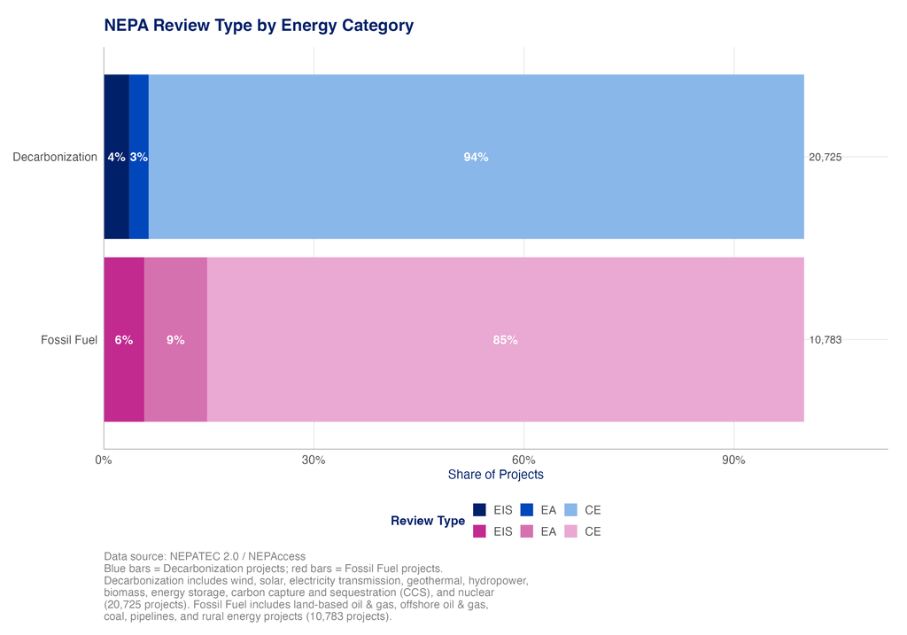

Figure 1: NEPA review type rates by energy category (Decarbonization vs. Fossil Fuel).

## Review Type by Technology

The technology view shows why the clean/fossil headline should not be overinterpreted. Some clean technologies have materially higher EIS shares than the decarbonization average. Some fossil categories remain highly CE-heavy because many oil and gas actions are processed through repeatable BLM or statutory CE pathways.

The figure below plots CE, EA, and EIS shares for all technology groups, sorted by categorical exclusion share from highest to lowest. The spread, from near-universal CE use (CCS, rural energy) to double-digit EIS rates (coal, offshore oil and gas, hydropower, wind), illustrates that a project’s technology type predicts its review pathway as reliably as its clean/fossil designation.

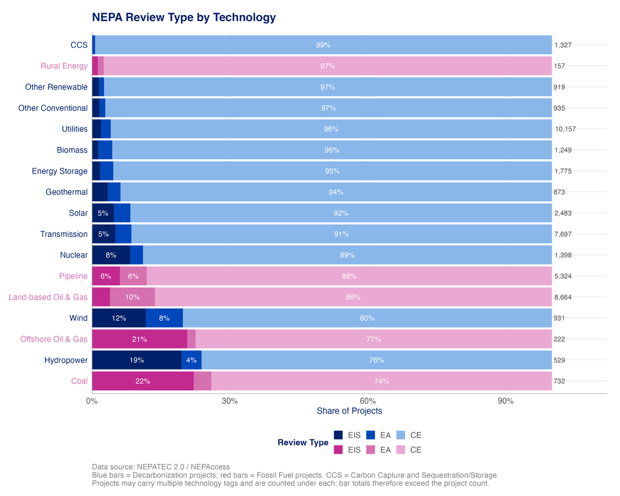

Figure 2: CE, EA, and EIS shares by technology group, sorted by CE share. Projects may carry multiple technology tags and are counted under each, so the project counts shown sum to more than the total number of projects.

## Linear vs. Non-linear Geometry

Projects are split by geometry into linear infrastructure — transmission lines, pipelines, and corridors — versus non-linear point or area projects (solar arrays, wind farms, geothermal fields, well pads, plants, and storage). The `is_linear` flag is derived from the NEPATEC project-type taxonomy and is advisory: a project carrying any linear label is treated as linear, since geometry is a property of the built infrastructure. The figure below shows CE, EA, and EIS shares within each geometry class, faceted by energy category.

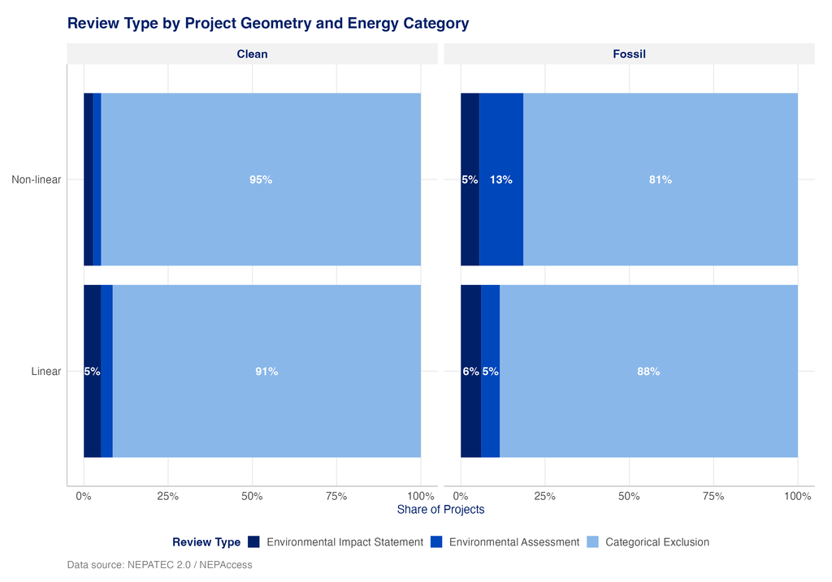

Figure 3: NEPA review type shares by project geometry (linear vs. non-linear) and energy category. Linear = transmission, pipelines, and corridors; non-linear = point or area projects.

## Within-Agency Comparisons

Agency controls help separate technology effects from agency practice. Within-agency review profiles are generated from the latest `review_rates_within_blm.csv` and `review_rates_within_doe.csv` outputs.

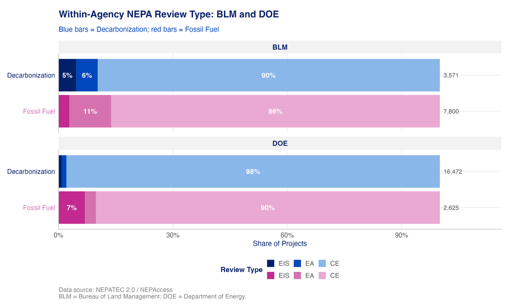

Figure 4: Within-agency NEPA review type shares — BLM and DOE by energy category. Blue bars = Decarbonization; red bars = Fossil Fuel. Facets show BLM (top) and DOE (bottom).

The BLM comparison is the more informative of the two: within a single land-management agency, the clean/fossil CE gap narrows relative to the headline rate, indicating that federal land exposure and repeatable permitting pathways, not energy category alone, drive a meaningful share of the headline difference. The DOE comparison points in a different direction: clean-energy DOE reviews are overwhelmingly CEs, likely because the DOE clean portfolio contains many financial-assistance and low-disturbance actions, while DOE fossil projects include a smaller and more heterogeneous set.

# Categorical Exclusion Citations

## Most-Cited CE Authorities

The CE citation distribution is concentrated in a relatively small set of authorities. These codes should be interpreted as document-level citation counts, not unique project counts. A project can have multiple CE citations, and some agency manuals encode several closely related categorical exclusions separately.

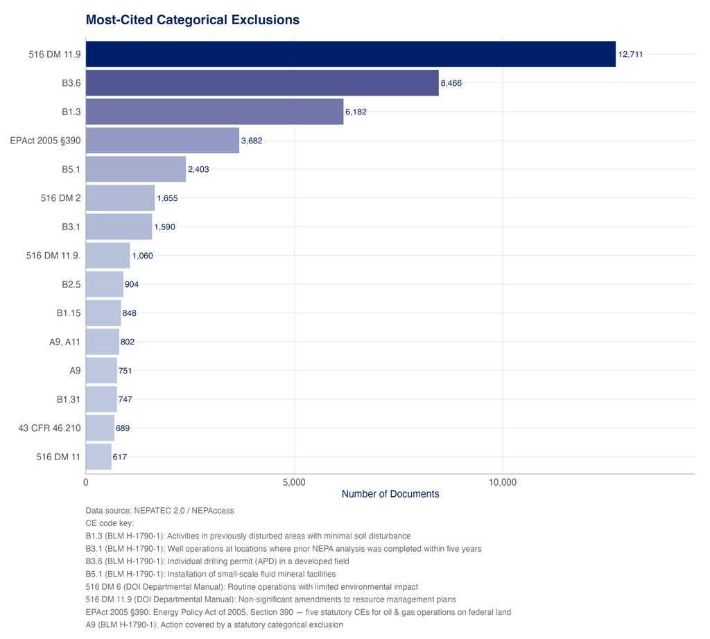

Figure 5: Top 15 most-cited CE authorities across all projects (gradient: dark = most cited).

## Clean vs. Fossil CE Profiles

The clean and fossil CE portfolios rely on different legal and administrative pathways.

Top CE citations by portfolio (decarbonization left, fossil fuel right):

Decarbonization

| CE Citation | Documents |
| --- | --- |
| B3.6 | 4,137 |
| B1.3 | 2,751 |
| 516 DM 11.9 | 2,202 |
| B5.1 | 1,922 |
| B3.1 | 714 |
| A9 | 503 |
| A9, A11 | 498 |
| B2.5 | 477 |

Fossil Fuel

| CE Citation | Documents |
| --- | --- |
| EPAct 2005 Section 390 | 3,661 |
| 516 DM 11.9 | 2,627 |
| B3.6 | 705 |
| 516 DM 6 | 439 |
| B3.1 | 295 |
| 516 DM 11 | 253 |
| B1.3 | 228 |
| B5.1 | 185 |

The fossil distribution is dominated by oil-and-gas-specific pathways, especially Section 390. The decarbonization distribution is more mixed, reflecting a broader set of technologies and agencies.

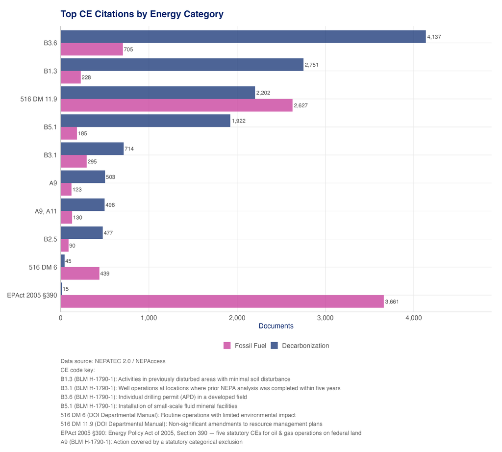

Figure 6: Top CE citations by energy category (Decarbonization = navy, Fossil Fuel = red).

## CE Citations by Agency

Agency-specific CE citation patterns are central to the story. The same high-level review type, “Categorical Exclusion”, can reflect very different institutional routines depending on whether the action is BLM oil and gas, BLM right-of-way work, DOE funding, or another agency’s infrastructure program.

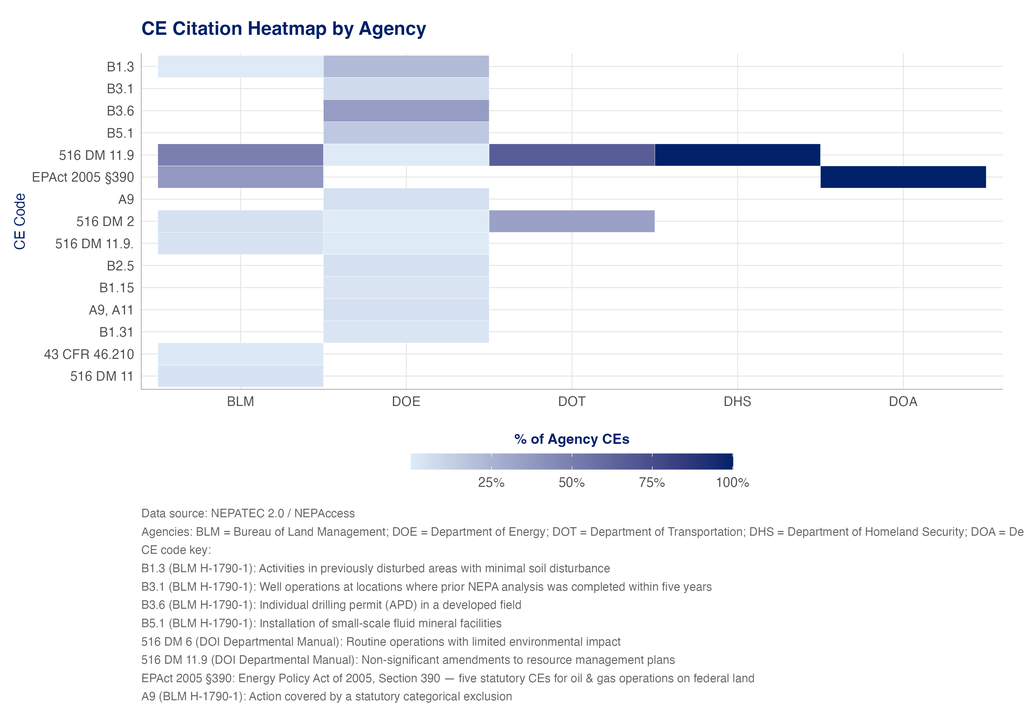

Figure 7: CE citation heatmap — CE codes (y-axis) by lead agency (x-axis). Fill intensity = share of each agency’s CE citations. Agency abbreviations listed in figure caption.

## CE Citations by Trigger

The CE-by-trigger table is currently limited to clean-energy projects because Deliverable 1 trigger classification has not yet been extended to fossil projects. The table below is generated from the latest `ce_by_trigger.csv` output.

| Clean-Energy Trigger | Leading CE Citation Pattern |
| --- | --- |
| Direct Action | B1.3, B3.6, B1.15, B1.31, B2.2 |
| Funding | B3.6, B5.1, B3.1, A9, A11, A9 |
| Land | 516 DM 11.9, 516 DM 2, 516 DM 11.9., 43 CFR 46.210, 516 DM 11 |
| Permit | B4.2, B3.1, B5.25, B1.24, B1.31 |
| Program | B3.6, B5.1, B1.7, B1.15, B2.2 |
| Property Transaction | B1.24, B1.3, B1.7, B4.9, A1 |
| Pma | B1.3, B4.6, B4.11, B1.19, B4.9 |
| Unknown | B3.6, B1.3, B.3.10, B1.15, B1.23 |

This is a high-value area for expansion once fossil triggers are classified. It would allow us to distinguish “fossil projects use more CEs” from “specific fossil authorities create repeatable CE pathways.”

# Geographic Distribution

## State-Level Patterns

The maps and tables count project-state records, so projects spanning multiple states can contribute to multiple state totals. This is appropriate for geographic footprint analysis, but it should not be interpreted as a unique-project denominator.

Top states by project-state count (decarbonization left, fossil fuel right):

Decarbonization

| State | Projects |
| --- | --- |
| South Carolina | 2,024 |
| Washington | 1,872 |
| California | 1,734 |
| Oregon | 1,303 |
| Colorado | 1,220 |
| Idaho | 962 |
| Arizona | 944 |
| Nevada | 909 |
| Wyoming | 688 |
| Texas | 602 |

Fossil Fuel

| State | Projects |
| --- | --- |
| Wyoming | 2,577 |
| New Mexico | 2,391 |
| California | 906 |
| Colorado | 764 |
| Texas | 428 |
| Utah | 406 |
| North Dakota | 373 |
| Alaska | 281 |
| Louisiana | 247 |
| Montana | 197 |

The fossil map is more visibly concentrated in Interior West oil-and-gas states. The decarbonization map is broader, with strong concentrations in the West, Pacific Northwest, California, and selected Southeastern and Atlantic states.

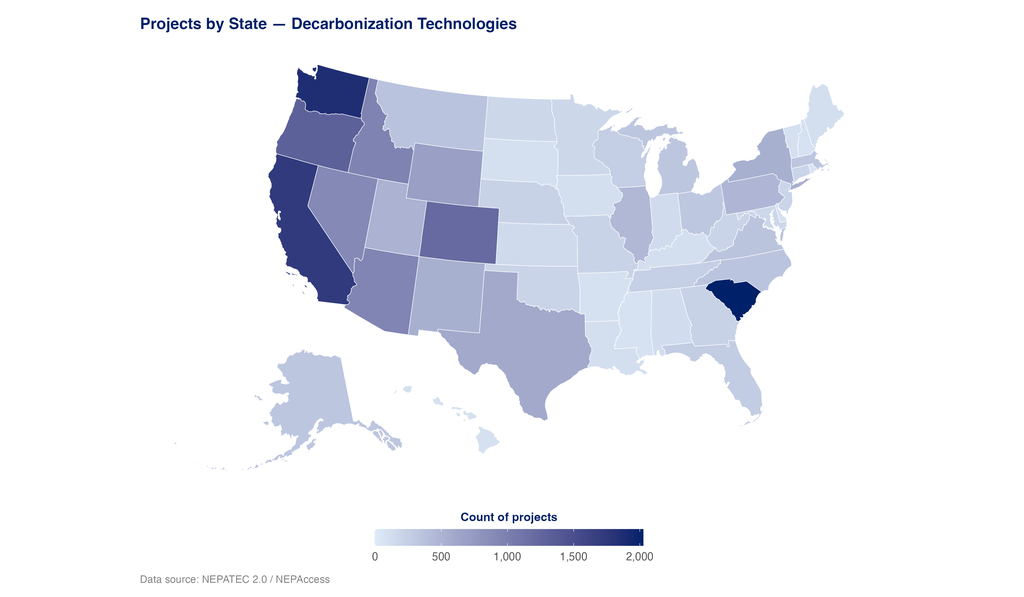

Figure 8: Decarbonization project counts by state (navy gradient, darker = more projects).

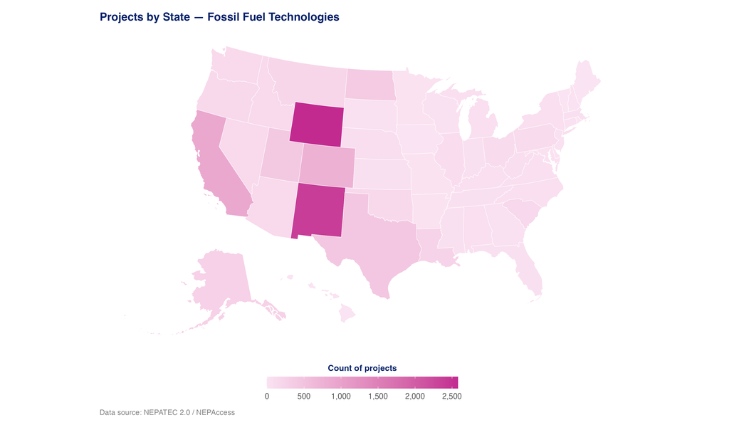

Figure 9: Fossil fuel project counts by state (red gradient, darker = more projects).

## County-Level Patterns

County maps provide a more granular view of project geography. They show fossil fuel activity clustering in oil-and-gas regions and decarbonization activity spreading across renewable, transmission, and federal-power geographies.

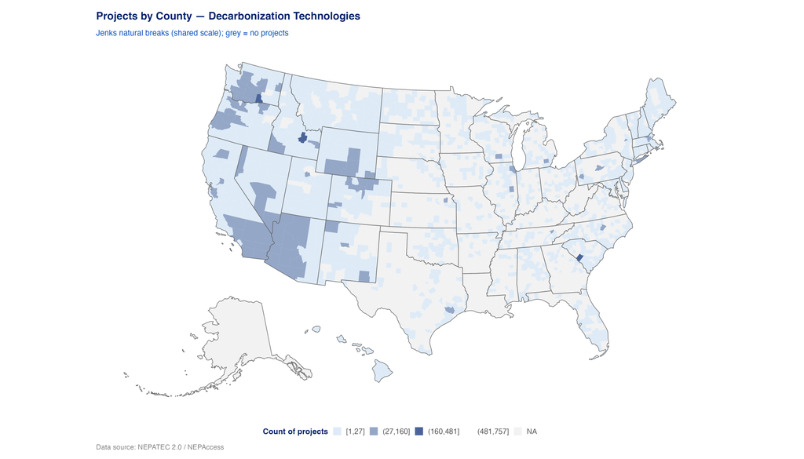

Figure 10: Decarbonization project counts by county (Jenks breaks, light to navy).

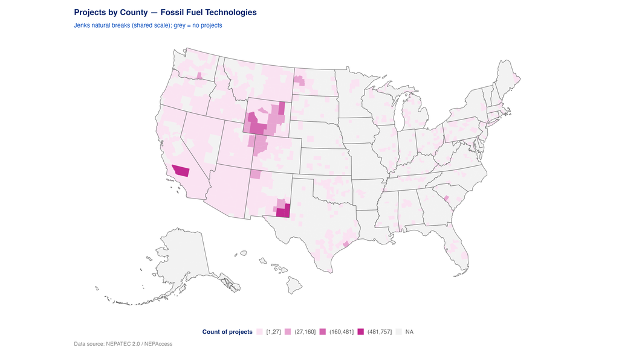

Figure 11: Fossil fuel project counts by county (Jenks breaks, shared scale, light to maroon).

## Process Type by State

The state-by-process maps show each state’s share of all national projects of a given review type within its energy category — for example, Texas Decarbonization CE projects as a share of all Decarbonization CE projects nationally. Colors use a square-root scale to surface variation when one or two states dominate. This helps identify where review activity concentrates by type, and supports targeted questions — for example, whether EIS-heavy states reflect project size, federal land exposure, agency practice, technology mix, or state-specific project portfolios.

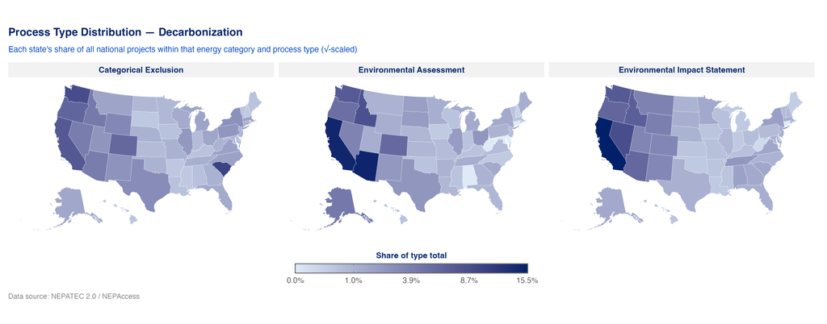

Figure 12: Each state’s share of all Decarbonization projects by process type (e.g., Texas Decarbonization CE ÷ all Decarbonization CE nationally). Color scale is square-root transformed to surface geographic variation.

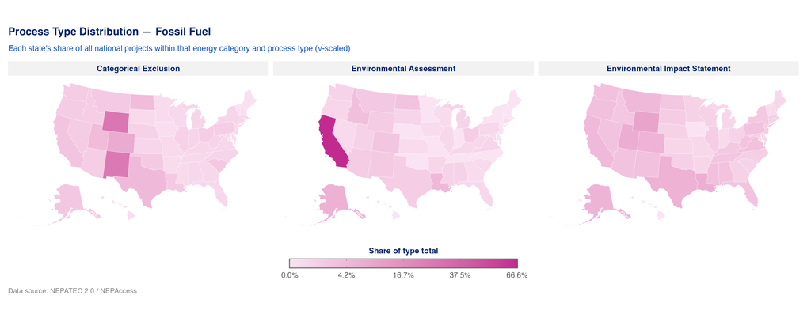

Figure 13: Each state’s share of all Fossil Fuel projects by process type (e.g., Texas Fossil Fuel CE ÷ all Fossil Fuel CE nationally). Color scale is square-root transformed to surface geographic variation.

# Geothermal vs. Oil and Gas

This comparison covers all lead agencies (BLM, USFS, DOE, and others). The Python builder classifies geothermal only within clean-energy projects and subsets the project table to clean geothermal, land-based oil and gas, and offshore oil and gas. The R analysis collapses land-based and offshore oil and gas into a single `Oil & Gas` comparison group.

Across all agencies, geothermal tracks closely with the decarbonization average. Geothermal has a 93.8% CE share, compared with 93.6% for the full decarbonization portfolio. Oil and gas is more review-intensive, with a 86.1% CE share and a higher EA share.

| Comparison Group | Projects | CE Share | EA Share | EIS Share |
| --- | --- | --- | --- | --- |
| Geothermal | 873 | 93.8% | 2.7% | 3.4% |
| Oil & Gas | 8,875 | 86.1% | 9.6% | 4.3% |

This figure answers a broad technology-comparison question: how geothermal projects compare with oil-and-gas projects across all lead agencies. It does not isolate public-land or BLM permitting pathways.

| Comparison Group | Projects | CE Share | BLM Share | Federal-Land Trigger Share |
| --- | --- | --- | --- | --- |
| Technology Groups |  |  |  |  |
| Geothermal (All Agencies) | 873 | 93.8% | 12.5% | 14.0% |
| Oil & Gas (All Agencies) | 8,875 | 86.1% | 78.3% | Not yet classified |
| Portfolio Averages |  |  |  |  |
| Decarbonization Average | 20,725 | 93.6% | 17.2% | 18.3% |
| Fossil Fuel Average | 10,783 | 85.2% | 72.3% | Not yet classified |

This is potentially one of the most important findings in the deliverable, but it should be framed carefully. If the policy question is whether geothermal generally moves through NEPA more like decarbonization or oil and gas, the all-agency comparison suggests geothermal is closer to the decarbonization average. If the policy question is whether BLM geothermal development faces a pathway more similar to oil and gas, that is a different question that this comparison does not answer.

Three control caveats bound how far this comparison should be read:

- **The comparison is an all-agency blend.** It pools BLM, USFS, DOE, and other lead agencies, so it mixes different permitting pathways and does not isolate any single agency’s practice.
- **A BLM-only control was considered and deliberately not included.** A public-land (BLM-lead) geothermal-versus-oil-and-gas comparison would be the right way to test the public-land question above, but it is out of scope for this version and is noted as a candidate follow-up rather than an available result.
- **The federal-land trigger share is not classified for oil and gas.** The comparison table’s Federal-Land Trigger Share column reads “Not yet classified” for the oil-and-gas rows because NEPA-trigger classification was not extended to the fossil portfolio; only the clean-energy (including geothermal) side carries trigger values.

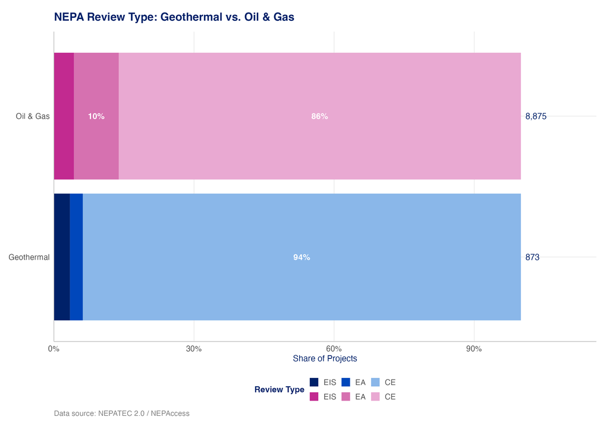

Figure 14: CE/EA/EIS rates — Geothermal vs. Oil & Gas (all lead agencies).

The state share figure shows all states with geothermal or oil-and-gas projects, ordered by geothermal share. Vermont is the most geothermal-dominant state in this comparison, with 7 geothermal projects and 0 oil-and-gas projects. Among states with at least 100 geothermal plus oil-and-gas projects, Nevada has the highest geothermal share, with 121 geothermal projects and 52 oil-and-gas projects.

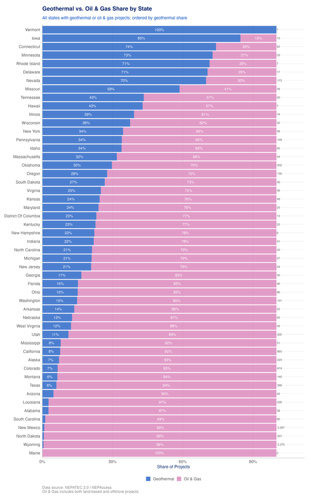

Figure 15: Geothermal vs. Oil & Gas project shares by state, ordered by geothermal share.

The state map encodes the same geothermal share metric as a diverging color scale: blue states are geothermal-dominant, red states are oil-and-gas-dominant, and purple indicates a roughly equal split between the two. States with no projects in either category are shown in grey.

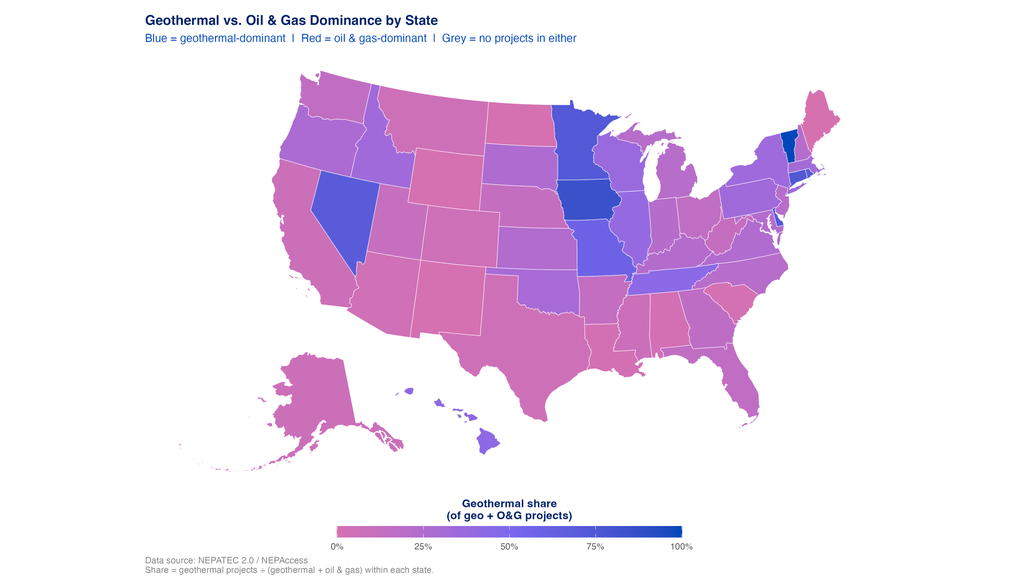

Figure 16: State-level geothermal vs. oil-and-gas dominance map (diverging scale: blue = geothermal-dominant, red = oil-and-gas-dominant).

# Visual Impact Analysis

The visual-impact module extracts full visual-section text for 1,591 of the roughly 2,918 EA/EIS projects (~55%; see the Coverage & Limitations page for what the remainder lack), then runs topic modeling, CEQ-anchored framing scoring, illustrative-excerpt sampling, and an interactive distinguishing-terms explorer. Section text is recovered via heading-anchored extraction (visual-resource heading detection plus same-or-shallower-depth termination, so subsections such as *Affected Environment* and *Environmental Consequences* are retained), with a contiguous-keyword-run fallback for projects whose documents lack clean heading hierarchies — most commonly land-based oil and gas EAs that rely on form-style templates. CE forms remain out of scope.

## Visual Analysis Universe

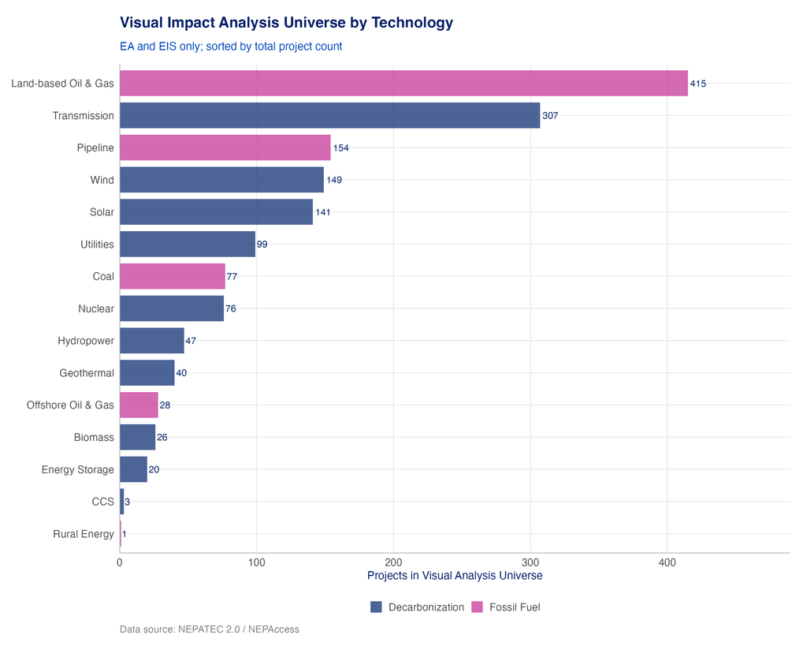

Figure 17: Visual analysis universe — project counts by technology and energy category.

Project counts by `tech_group` and `energy_group` indicate where the visual analysis has substantive coverage and where it is thin. Solar, wind, transmission, land-based oil and gas, and pipelines anchor the high-volume cells. Thinly-sampled cells (CCS, offshore oil and gas EA, coal EA, nuclear EA) are visible in the figure and should be interpreted as illustrative rather than statistical.

## Word Cloud Comparison

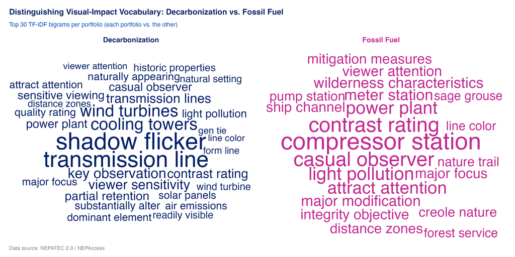

Figure 18: TF-IDF word clouds — bigrams most distinctive to each portfolio (EA and EIS combined). Top 30 terms per panel.

## Section Length

At the portfolio level, decarbonization and fossil fuel projects produce visual sections of similar median length, but the decarbonization distribution is wider, driven by wind, solar, and transmission EISs that generate long dedicated glare and viewshed sections.

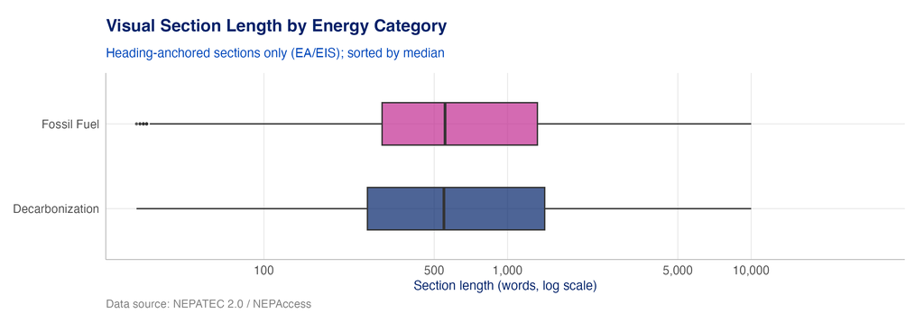

Figure 19: Visual section length (words) by energy category — Decarbonization (navy) vs. Fossil Fuel (red). Heading-anchored EA/EIS sections only; sorted by median.

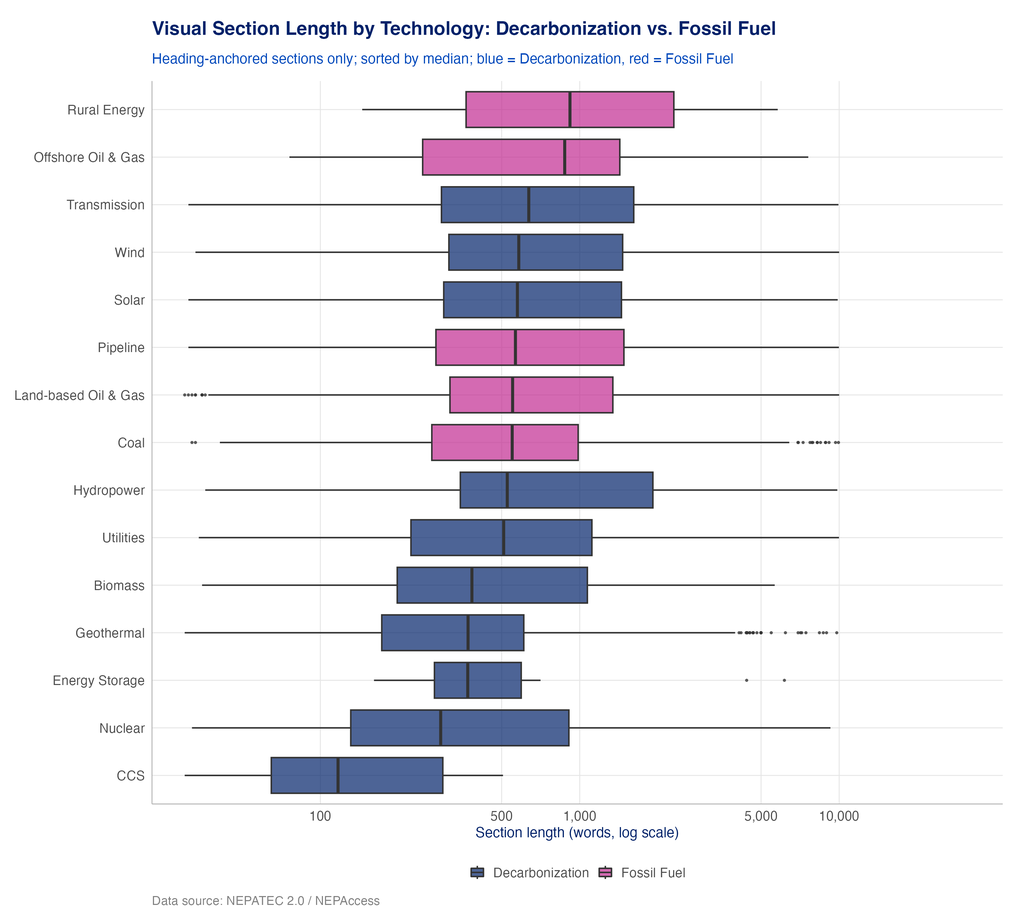

Figure 20: Visual section length (words) by technology group — Decarbonization (navy) vs. Fossil Fuel (red). Sorted by median; heading-anchored sections only.

## Illustrative Excerpts

The table below pulls representative passages from the visual-impact section text used as input to the topic and framing models, grouped by energy category. Each row shows the project’s process type, technology, lead agency, and a passage drawn from the sentence-filtered visual analysis text. These excerpts are intended to be directly quotable in briefings.

Table 1: Representative visual-resource excerpts by energy category. Sections drawn from heading-anchored extractions; full excerpt text shown.

| Process | Tech | Lead Agency | Project | Excerpt |
| --- | --- | --- | --- | --- |
| Decarbonization |  |  |  |  |
| EA | Biomass | Department of Energy | Chariton Valley Biomass Project | “OGS Site The Proposed Action would not significantly impact the current aesthetics or viewscapes at or near the OGS plant. Although the proposed new buildings would be built on slightly higher ground… |
| EIS | Biomass | Forest Service | Mt. Bachelor Ski Area Improvements Project | “45 and 46 (The Cascade Lakes National Scenic Byway). 45 and 46 (The Cascade Lakes National Scenic Byway). Environmental Issue No-Action Alternative Alternative A – No New Catchline - On-mountain Impr… |
| EIS | Geothermal | Forest Service | Big Creek Geothermal Leasing Project, Salmon-Cobalt and N... | “Impacts under Alternative 2 could involve equipment, structures, roads, and operations, which would alter the characteristic landscape and be sources of light and glare. Natural landscape features an… |
| EIS | Hydropower | Department of Energy | Hydropower Licenses: Wilder Hydroelectric Project, Federa... | “The Connecticut River Valley is recognized for its scenic mountains, historic villages, and open farmland. The mix of open space, villages, farms, country roads, mountainous terrain, historic archite… |
| EIS | Hydropower | Bureau of Reclamation | Reinitiation of Consultation on the Coordinated Long-Term... | “Visual effects are dependent upon the viewpoint of individuals because each person can respond differently to changes in the physical environment depending upon expectations, historical perspective, … |
| EIS | Nuclear | Nuclear Regulatory Commission | Seabrook Station License Renewal | “The onshore wind turbines, which are over 300 ft (100 m) tall and spread across multiple sites, would dominate the view and would likely become the major focus of attention. The site is visible from … |
| Fossil Fuel |  |  |  |  |
| EA | Coal | Bureau of Land Management | Warrior Met Coal Mining, LLC Mine No. 4 Expansion Coal Lease | “Together, they form the overall impression of an area referred to as the landscape character. Visual Resource Management (VRM) classifications are established for public lands so that visual resource… |
| EA | Land-based Oil & Gas | Bureau of Land Management | Midway Sunset; Monarch Master Development Plan | “The interim visual resource management objective of this project site is assigned as Class IV. Class IV management objectives allow for major modification of the landscape; as such, no visual contras… |
| EIS | Land-based Oil & Gas | Bureau of Land Management | Moab Master Leasing Plan | “(Visual Resource Management/Auditory Management/Resource Overview), Natural Soundscapes Description of Changes Location in MLP/FEIS Add text to acknowledge the importance of National Park Service vie… |
| EIS | Pipeline | Corps of Engineers--Civil Works | Lake Ralph Hall Regional Water Supply Reservoir Project | “During construction of the proposed dam and embankment the viewshed of travelers along FM 1550, FM 904, and SH 34 would be affected as the construction would be visible from the roadway. After constr… |
| EIS | Pipeline | Department of Energy | Northern Lights 2023 Expansion Project | “The closest residential structure is about 725 feet from the existing aboveground facility with several trees on the residential property providing a natural vegetative screen of the site. However, g… |

## Framing Analysis

Framing scores are CEQ §1508.27-anchored and computed with negation-aware phrase matching, so *no significant adverse impact* counts as low-adversity rather than high-significance. Three axes are measured:

- **Significance**: share of visual-impact sentences using high-severity language (*substantial*, *major*, *severe*) vs. low-severity language (*minor*, *negligible*, *less than significant*).
- **Adversity**: share of directional-impact sentences framing impact as negative (*adverse*, *detrimental*, *degrade*, *harm*) vs. positive or no-effect (*beneficial*, *enhance*, *no effect*).
- **Mitigation strength**: share of mitigation sentences with specific, action-level commitments (*shall install*, *required to*, *design feature*) vs. weak or residual language (*residual impact*, *unavoidable*, *cannot fully mitigate*).

This approach is conceptually similar to sentiment analysis, but uses domain-specific lexicons rather than general-purpose sentiment tools. Standard sentiment tools (VADER, TextBlob) would score nearly all NEPA text as strongly negative (the word *impact* alone triggers a negative score) because they are trained on social media and reviews where “impact” carries negative valence. In NEPA, “impact” is a neutral term of art; a finding of “no significant adverse impact” is a positive outcome but would register as strongly negative under general sentiment scoring. The framing measures here are calibrated to the actual meaning of CEQ terminology.

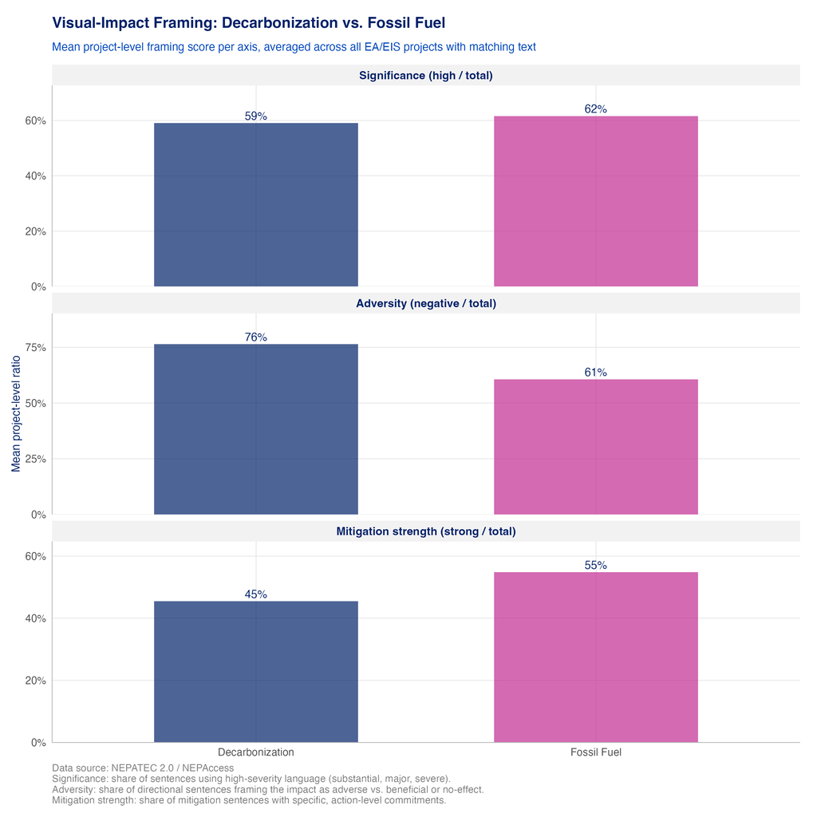

Figure 21: CEQ §1508.27-anchored framing scores by energy category — significance, adversity, and mitigation strength. Negation-aware phrase matching.

Table 2: Representative sentences illustrating each framing measure, drawn from projects at the high and low end of each ratio, grouped by portfolio.

| Measure | Framing | Sample text |
| --- | --- | --- |
| Decarbonization |  |  |
| Significance | High | “actions that may create significant landscape alternations that would be obvious to the” |
| Significance | Low | “where minor or tolerable delays are experienced by motorists.” |
| Adversity | Negative | “address disproportionately high and adverse human health or environmental effects of” |
| Adversity | Positive | “reduce light glare and scatter helping to improve night sky viewing opportunities.” |
| Mitigation | Strong | “VR-1 states that structures shall be placed at the maximum feasible distance from roadway and trail” |
| Mitigation | Weak | “would remain visible from on-site and off-site locations.” |
| Fossil Fuel |  |  |
| Significance | High | “the adjacent area with regard to location, scale, shape, color and orientation of major landscape” |
| Significance | Low | “The Proposed Action would create minor changes to the landscape that would be mitigated” |
| Adversity | Negative | “The proposed project would not have any major permanent adverse impacts to the viewshed in the” |
| Adversity | Positive | “deemed necessary by the BLM to maintain or improve habitat values.” |
| Mitigation | Strong | “E&B shall comply with all applicable federal, tribal, state, and local laws during project” |
| Mitigation | Weak | “Riparian and wetland habitats associated with the lateral would likely remain in place and” |

Comparing the two portfolios: decarbonization projects carry meaningfully higher adversity scores than fossil fuel projects. This is not because solar and wind are more harmful to visual resources; it reflects that wind, solar, and transmission EISs document site-specific adverse effects explicitly (viewshed intrusion, glare, landscape character alteration) rather than relying on residual or no-effect language. Fossil fuel documents score higher on significance framing, likely because oil and gas EAs invoke CEQ significance thresholds and context language more routinely as a matter of form. Fossil fuel documents also score higher on both mitigation ratio and mitigation specificity — projects subject to formal BLM mitigation plans or Record of Decision commitments produce more enumerated, action-level language (*shall install*, *required to*, *design feature*) even when adversity framing is lower. The decarbonization portfolio’s higher adversity framing without a corresponding mitigation specificity premium likely reflects that wind and solar EISs acknowledge site-specific visual effects explicitly but address them through design standards and programmatic commitments rather than project-level enumerated actions.

A typical decarbonization EIS will name the impact directly — *“moderate, long-term adverse impacts due to altering the scenic attractiveness rating from typical to indistinctive”* — and resolve it by invoking a design standard: *“anti-reflective PV panel surfaces would minimize glare”* or *“deviations must repeat the form, line, color, and texture of the surrounding landscape”* (USFS Scenic Integrity Objective). A fossil fuel EA under a formal BLM plan of development tends to write it differently: *“operator shall install opaque screening of specified height along the north perimeter”* or *“facilities required to use earth-tone paint matching an approved Munsell color”* — inspectable, project-specific commitments that produce more action-level language by default. The higher fossil fuel mitigation specificity score is therefore a product of the BLM permit-and-plan regime for oil and gas rather than evidence of stronger mitigation outcomes.

## VRM Contrast Analysis

Elements with fewer than 5 projects recorded across both energy categories are excluded from the chart — Scale is the primary example, appearing in only one decarbonization project and no fossil fuel projects. The chart shows rated projects only (Weak, Moderate, Strong); projects with no recorded contrast for a given element are excluded.

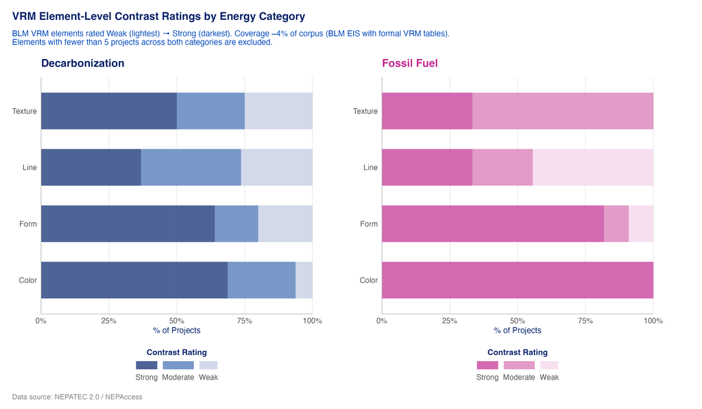

Figure 22: BLM VRM element-level contrast ratings — Decarbonization (navy scale) and Fossil Fuel (red scale). Coverage ~4% of corpus (BLM EIS with formal VRM contrast tables).

## Topic Analysis

**Note**

**A note on “contrast” appearing in multiple topics.** In BLM Visual Resource Management (VRM) terminology, *contrast* is the technical measure of how visually distinct a project is from its surrounding landscape, assessed across form, line, color, texture, and vividness. It is the foundational concept in virtually all federal visual impact analysis, appearing in approximately 45% of documents in this corpus. Because NMF topic components are additive (each document’s representation is a weighted mix of all four topics), a term that is common across the corpus will have non-zero weight in multiple components. What distinguishes the two VRM-heavy topics is their *secondary* vocabulary, not their anchor term: Topic 0’s secondary terms (solar, sensitivity, moderate, glare) reflect applied contrast-rating outcomes on solar projects; Topic 3’s (managed, VRI, classes, integrity, dominate) reflect the formal BLM VRM compliance framework in O&G and pipeline EIS documents.

Four topics emerge from NMF applied to the sentence-filtered visual-impact text (~1,310 heading-anchored documents), ordered below by project count (largest first):

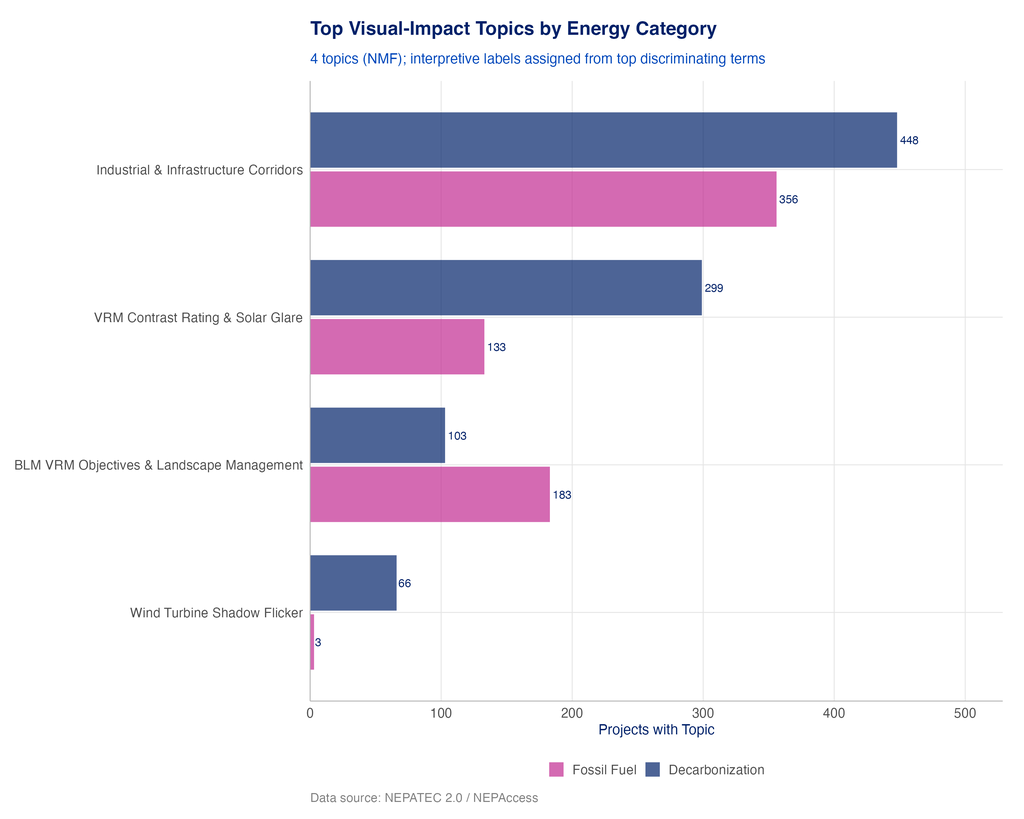

Figure 23: NMF topic prevalence — project count by topic and energy category.

Table 3: NMF Visual-Impact Topic Summary.

| Topic | Top terms | Description |
| --- | --- | --- |
| Industrial & Infrastructure Corridors | transmission, light, visual character, river, line, lighting, industrial, structures, plant, glare, terminal, station | Visual impact of linear and industrial facilities — O&G pipelines, transmission lines, LNG terminals, substations. Language centers on structures, lighting, visual character of river and byway viewshe… |
| VRM Contrast Rating & Solar Glare | contrast, visual contrast, rating, objectives, glare, solar, sensitivity, moderate, contrast rating, line, viewer, light | BLM VRM contrast rating methodology applied to solar and transmission projects. Documents score contrast of form, line, color, and texture against the characteristic landscape; glare from panels is a … |
| BLM VRM Objectives & Landscape Management | objectives, contrast, managed, rating, visual contrast, integrity, river, vri, landscape character, line, sensitivity, moderate | Formal BLM VRM compliance framework: managed VRM classes, Visual Resource Inventory sensitivity, dominance, landscape character, and scenic integrity objectives. Primarily O&G and pipeline EIS documen… |
| Wind Turbine Shadow Flicker | shadow, flicker, shadow flicker, turbine, wind, turbines, hours, receptor, year, wind turbine, wind turbines, shadows | Rotating turbine blades cast moving shadows on nearby receptors. Analysis quantifies annual shadow hours per receptor and compares against regulatory thresholds (often 30 hours/year). |

[figure not shown]

Figure 24: Top NMF term weights per topic (lollipop chart). Panels ordered by project count (largest first). Weights are not probabilities — compare within panels only.

### Topic Validation

The elbow analysis formalises why four topics is the right choice. Reconstruction error — how well the topic model re-creates the original term-frequency matrix — drops sharply from k=2 to k=3, then makes a smaller but meaningful improvement at k=4. From k=4 onward the error flatlines: adding a fifth or sixth topic produces no reduction in reconstruction error, and those extra components receive zero project assignments at inference time. Reducing to three topics would collapse the two distinct VRM subtopics (solar-glare contrast rating vs. O&G landscape management objectives) into one coarser category. The flat term-weight profile of Topic 2 (Industrial & Infrastructure Corridors) is not grounds for adding more topics; it is evidence that O&G, pipeline, and transmission projects share visual-impact prose at a level the NMF vocabulary cannot separate, regardless of k.

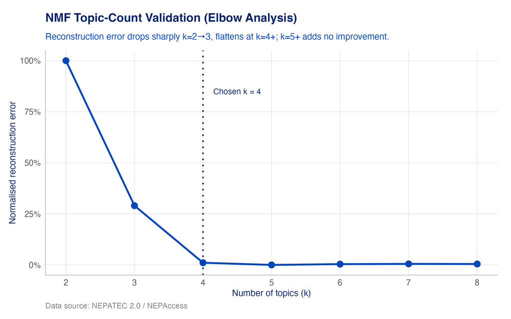

Figure 25: NMF topic-count validation — normalised reconstruction error by k. Dotted line marks chosen k=4.

# Reproduction

Run from the repository root in the `nepa` conda environment:

```bash
conda run -n nepa python phase2/code/deliverable03/02_build_nepa_reviews.py
Rscript phase2/code/deliverable03/04_create_figures.R
```

Outputs are written to:

- `phase2/data/analysis/deliverable03/`
- `phase2/output/deliverable03/`

*Draft generated 2026-08-21 | NEPA Decarbonization Technology Analysis - Phase 2, Deliverable 3*